# Big Picture

## An urgent mission for Jack

## **Background information: Balance between development and climate**

Imagine your life back in the 1990s. Everything was peaceful and simple, with people enjoying the face to face contact with each other and nature. There wasn’t much to worry about, except for some little problems in their daily lives. The cities grew bigger and bigger, and the nights were extended by the blinding lights shining in windows. It was a change that brought us the city of stars, but also blinded us from seeing a full sky of stars. The Greenhouse gases released by the rapid development have quietly shrouded us, but there comes a cost for the growth. It is hard to reckon why our economics are rising, while Venice is sinking. Maybe, in the year 2022, it is time for us to take a step back from pursuing growth and balance our life with the climate in a more sustainable way.

## **The story begins…**

Bridgton is a peaceful and beautiful town. One day in 2018, the town was instantly flooded by a sudden fog. People screamed in the fog and fled in panic. Jack, a wizard, was trapped in a small library, waiting for the fog to dissipate. However, the dense fog didn’t disperse as expected, and those who walked into the fog never returned. From the news, Jack realized that the fog was actually greenhouse gas which was neglected by human beings for centuries, and it started to spread to the whole world and harm the planet. Jack can use his magic to travel back to 1990. To save the planet, Jack decided to explore the factors influencing the emission around the globe during these years. He will travel back to 1990 after having a deep understanding of the situation. Then, he immediately started to do the research in the library…

## **Question: What is the trend of globe emissions?**

To understand the current situation, Jack did a trend plot to make sure that the total emission of greenhouse gas is increasing over years. As you can see from the line graph, the total emissions line increases gradually with few fluctuations from 1990 to 2018 around the world. There’s a line that shows emissions increase over years. This result is not surprising, considering the rising world population and increasing world production. As a result, Jack aware the urgency of improvement for the world, and he plans to go deeper and look at the global distribution of emission in order to have a well-rounded understanding of the situation.

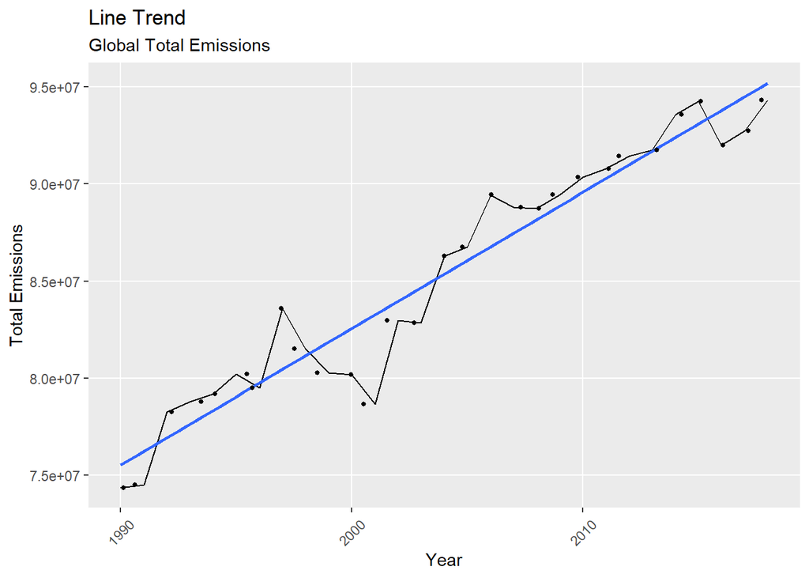

## **Global overview of emission distribution:**

- Total emission distribution

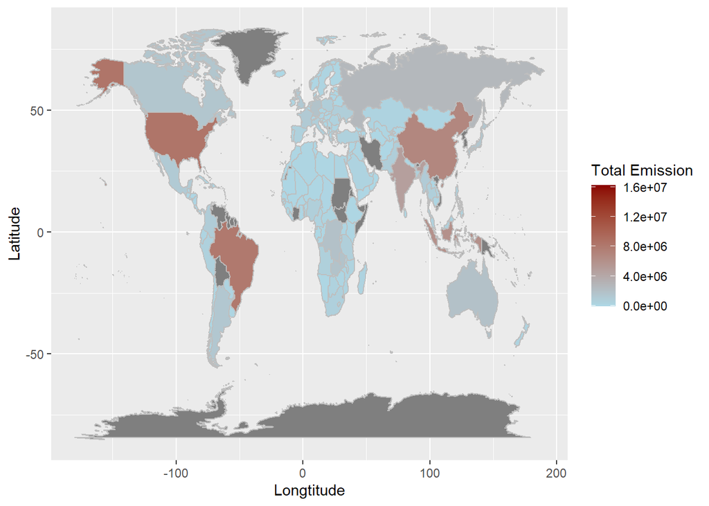

- Agricultural emission distribution

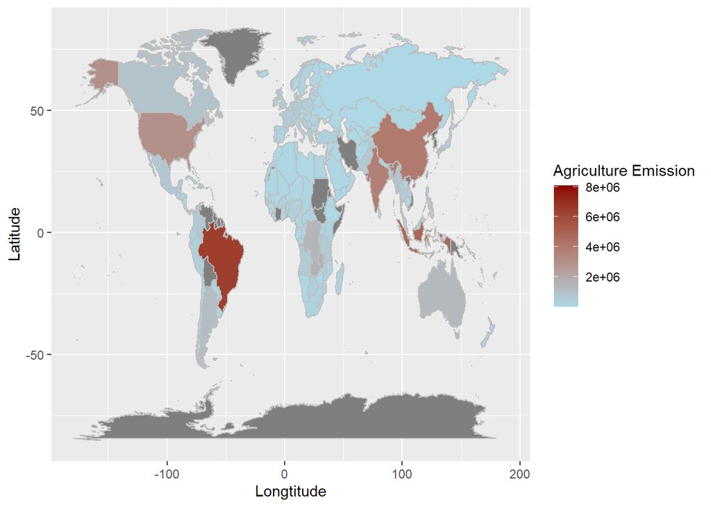

- Energy Consumption distribution

But still, there is more to consider. Jack finds energy consumption contributes even more than the agriculture sector. When he looks at the energy consumption map, only the United States stands out. The total energy consumption in the United States is doubled compared to any other country in the world. On average, the consumption level in the US is the highest. In this way, energy consumption greatly contributes to total emissions. Energy is simply more available, affordable, and needed for the larger living area than in other places. It has positive relationship with total emissions. Perhaps the fact that the most common way of commuting is by automobile also contributes a lot to greenhouse gases. On the other hand, this high level of energy consumption actually boosts the economy’s growth, and it is pretty efficient in this way. But for our common good, perhaps it’s better to try to adapt to a greener way — switching to an electric vehicle, for example.

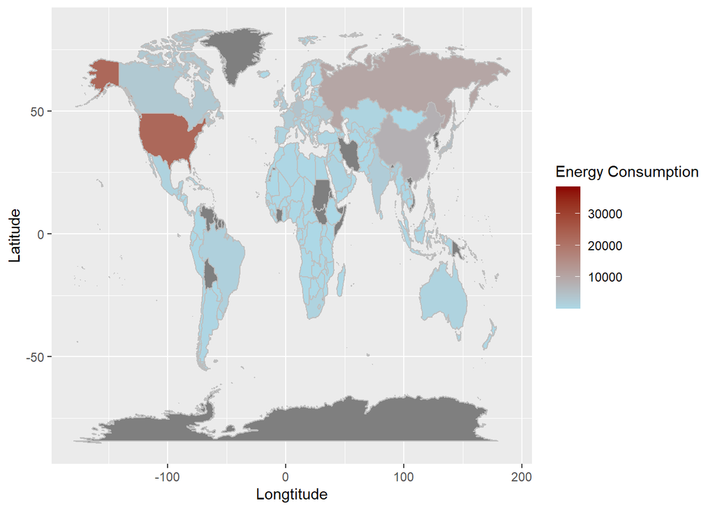

## **External factors breakdown:**

After Jack evaluates the distribution of emission situation around the globe, he has understood both agriculture and energy are important indicators of total emissions. What about external factors such as GDP and population? What’s their relationship with total emissions? In the following graphs, the dots in the left represent the total emissions of GDP, and the dots in the right represent the total emissions of Population, and the blue lines in both graphs help to direct the trend. With more population and GDP, perhaps emission is the side back of economic and social development. While the relationship between GDP and total emission is stronger than the relationship between population and total emission, they both have positive relationship with total emissions.

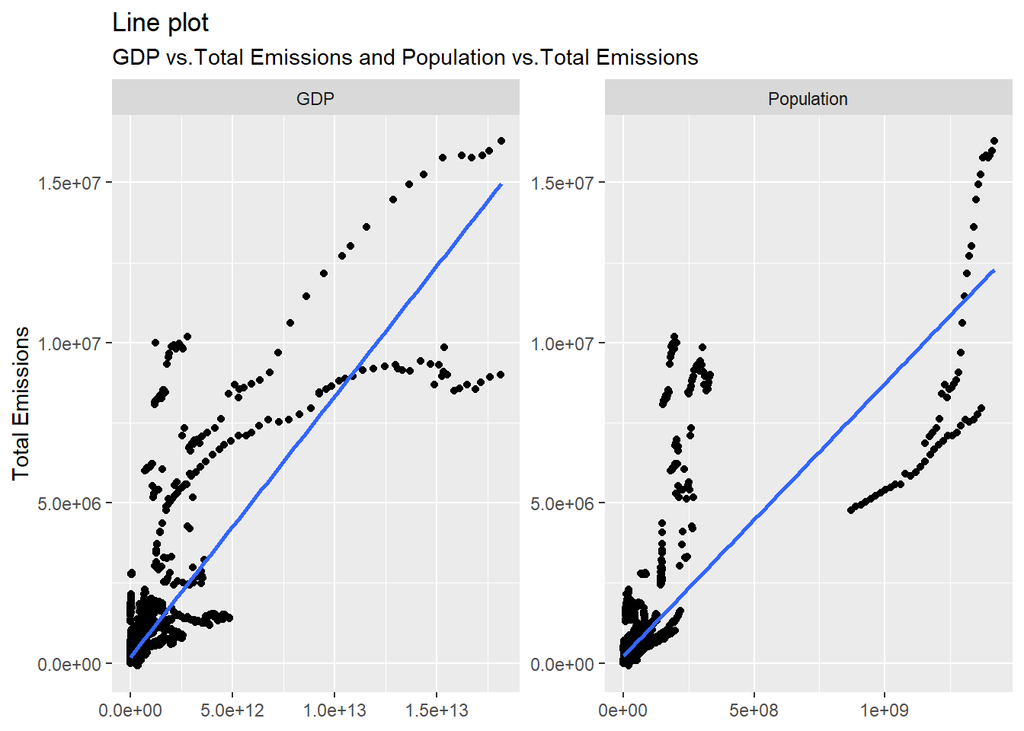

## **Interactive Plots:**

What indicator do you want to explore？

Here we have an interactive dashboard for you to explore emissions from all over the world at your interest: link

- Links: https://finalprojecta.shinyapps.io/FinalProject/
- We have a complete table for you to look at the country, year, population, gdp, energy_per_capita, energy_per_gdp, primary_energy_consumption, source_of_emissions, total_ghg.(kilotonnes), Agriculture _emission(kilotonnes), and agri_ghg_total between 1990-2018. Users could compare the difference in the amount for specific indicators of emissions between years. Also, users can choose the data by ascending order or descending by clicking the button. A search column is up the right, which allows users to explore any information that they are interested in. For users’ convenience, we also allow them to choose 10, 25, 50, or 100 entries. Users can explore whatever information because the table gives them the maximum flexibility.
- Links: https://finalprojecta.shinyapps.io/FinalProject2/
- Additionally, the world map displays the intensity of indicators. It covers data from 153 countries. You may choose any indicators and compare them between countries. For example, you are able to adjust all the variables such as agri_ghg_total and energy_per_capita at different years to see the corresponding world map color and distribution. While deeper color refers to larger value, more slight color means the value is comparably lower.

## **Conclusion&Discussion:**

With the mission to save the planet, Jack explores the distribution of emission situation around the globe and factors influencing the total emissions. He finds that agriculture and energy consumptions are two important factors contributing to global emissions, and he also learns areas that are in severe condition, thus needs urgent improvement. In this way, he will have a focus or direction to assist with reduction of greenhouse gas emissions after travelling back to 1990. To understand factors influencing emissions in a more well-rounded way, he even investigates external factors like GDP and population. By exploring relationship between population & total emissions and GDP & total emissions, Jack would be able to signal people to develop the economy in a more sustainable way, and avoid climate change as the cost of growth. And there are several recommendations to mitigate the greenhouse gas emissions. Perhaps practicing rational grazing to sequester carbon in the soil, making power on-site with renewables and other climate-friendly energy resources, controlling the population growth, and promoting inclusive and suitable economic growth.